# Project 2: Data Mining, Classification, Prediction

SDS322E

# Mining, Classification, Prediction

## Jennifer Chen (JC89777)

### Introduction

*The data I am using for this project comes from the “plantTraits” dataset in R studio. I chose this dataset because it has 31 variables (including both numeric and binary variables) and 136 observations which provides a lot of data and values for performing classification and prediction.*

*In order, the plantTraits variables are pdias (diaspore mass in mg), longindex (seed bank longevity), durflow (flowering duration), height (plant height as an ordered factor), beglow (time of first flowering as an ordered factor), mycor (mycorrhizas-symbiotic relationship of plant and fungus-as an ordered factor), vegaer (aerial vegetative propagation as an ordered factor), vegsout (underground vegetative propagation as an ordered factor), autpoll (selfing pollination as an ordered factor), insects (insect pollination as an ordered factor), wind (wind pollination as an ordered factor), lign (woody plant), piq (thorny plant), ros (rosette plant), semiros (semi-rosette plant), leafy (leafy plant), suman (summer annual), winan (winter annual), monocarp (monocarpic perennial), polycarp (polycarpic perennial), seasaes (seasonal aestival leaves), seashiv (seasonal hibernal leaves), seasver (seasonal vernal leaves), everalw (evergreen leaves), everparti (partially evergreen leaves), elaio (fruits dispersed by ants), endozo (endozoochorous fruits), epizo (epizoochorous fruits), aquat (aquatic dispersal fruits), windgl (wind dispersed fruits), and unsp (unspecialized seed dispersal mechanism).*

```r
library(tidyverse)
plant_data <- read_csv("Plant Traits Data.csv")
plant_data %>% glimpse()
```

```
## Rows: 136
## Columns: 32
## $ X1        <chr> "Aceca", "Aceps", "Agrca", "Agrst", "Ajure", "Allpe", "Anaa…
## $ pdias     <dbl> 96.84, 110.72, 0.06, 0.08, 1.48, 2.33, 0.38, 2.55, 1.48, 0.…
## $ longindex <dbl> 0.00000000, 0.00000000, 0.66666667, 0.48888889, 0.47619048,…
## $ durflow   <dbl> 2, 3, 3, 2, 3, 3, 3, 3, 3, 3, 4, 5, 3, 2, 3, 3, 3, 4, 2, 2,…
## $ height    <dbl> 7, 8, 2, 2, 2, 5, 2, 2, 3, 2, 5, 5, 3, 8, 3, 3, 5, 5, 4, 8,…
## $ begflow   <dbl> 5, 4, 6, 7, 5, 4, 6, 3, 7, 4, 6, 7, 4, 4, 6, 5, 6, 6, 8, 4,…
## $ mycor     <dbl> 2, 2, 2, 1, 2, 0, 2, 2, 2, 2, 1, 2, 2, 2, 2, 0, NA, 2, 2, N…
## $ vegaer    <dbl> 0, 0, 0, 2, 2, 0, 0, 0, 0, 0, 0, 0, 0, 0, 0, 0, 0, 0, 0, 0,…
## $ vegsout   <dbl> 0, 0, 1, 0, 0, 0, 0, 2, 0, 0, 1, 0, 1, 0, 1, 0, 0, 1, 0, 0,…
## $ autopoll  <dbl> 0, 0, 0, 0, 1, 3, 3, 1, 0, 2, 1, 0, 0, 0, 0, 3, 0, 1, 0, 0,…
## $ insects   <dbl> 4, 4, 0, 0, 3, 3, 2, 3, 3, 0, 0, 0, 4, 0, 0, 0, 4, 3, 3, 0,…
## $ wind      <dbl> 0, 0, 4, 4, 0, 0, 0, 0, 0, 3, 3, 3, 0, 4, 4, 0, 0, 0, 1, 4,…
## $ lign      <dbl> 1, 1, 0, 0, 0, 0, 0, 0, 0, 0, 0, 0, 0, 1, 0, 0, 0, 0, 1, 1,…
```

[output cut: 19 more lines]

```r
plant_data %>% summarize(n())
```

```
## # A tibble: 1 x 1
##   `n()`
##   <int>
## 1   136
```

```r
sum(is.na(plant_data))  #need to remove NAs for clustering
```

```
## [1] 166
```

```r
plant_data <- plant_data %>% na.omit
plant_data %>% summarize(n())
```

```
## # A tibble: 1 x 1
##   `n()`
##   <int>
## 1    78
```

### Cluster Analysis

```r
library(cluster)
clust_data <- plant_data %>% dplyr::select(2:32)
clust_data %>% head()
```

```
## # A tibble: 6 x 31
##    pdias longindex durflow height begflow mycor vegaer vegsout autopoll insects
##    <dbl>     <dbl>   <dbl>  <dbl>   <dbl> <dbl>  <dbl>   <dbl>    <dbl>   <dbl>
## 1  96.8      0           2      7       5     2      0       0        0       4
## 2 111.       0           3      8       4     2      0       0        0       4
## 3   0.06     0.667       3      2       6     2      0       1        0       0
## 4   0.08     0.489       2      2       7     1      2       0        0       0
## 5   1.48     0.476       3      2       5     2      2       0        1       3
## 6   2.33     0.5         3      5       4     0      0       0        3       3
## # … with 21 more variables: wind <dbl>, lign <dbl>, piq <dbl>, ros <dbl>,
## #   semiros <dbl>, leafy <dbl>, suman <dbl>, winan <dbl>, monocarp <dbl>,
## #   polycarp <dbl>, seasaes <dbl>, seashiv <dbl>, seasver <dbl>, everalw <dbl>,
## #   everparti <dbl>, elaio <dbl>, endozoo <dbl>, epizoo <dbl>, aquat <dbl>,
## #   windgl <dbl>, unsp <dbl>
```

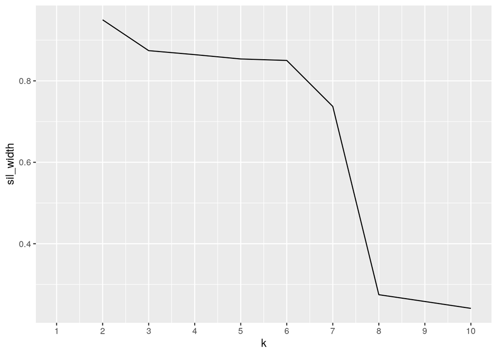

```r
# finding silhouette width
sil_width <- vector()
for (i in 2:10) {
    kms <- pam(clust_data, k = i)
    sil_width[i] <- kms$silinfo$avg.width
}
ggplot() + geom_line(aes(x = 1:10, y = sil_width)) + scale_x_continuous(name = "k",
    breaks = 1:10)
```

```r
# PAM clustering
pamdata <- clust_data %>% pam(k = 2)
pamdata
```

```
## Medoids:
##      ID   pdias longindex durflow height begflow mycor vegaer vegsout autopoll
## [1,] 35    2.45       0.2       4      3       5     2      0       0        3
## [2,] 59 1684.30       0.0       3      6       3     1      0       2        1
##      insects wind lign piq ros semiros leafy suman winan monocarp polycarp
## [1,]       1    0    0   0   0       1     0     0     0        0        1
## [2,]       3    0    1   1   0       0     1     0     0        0        1
##      seasaes seashiv seasver everalw everparti elaio endozoo epizoo aquat
## [1,]       0       0       0       1         0     0       0      1     0
## [2,]       1       0       0       0         0     0       1      0     0
##      windgl unsp
## [1,]      0    0
## [2,]      0    0
## Clustering vector:
##  [1] 1 1 1 1 1 1 1 1 1 1 1 1 1 1 1 1 1 1 1 1 1 1 2 1 1 1 1 1 1 1 1 1 1 1 1 1 1 1
## [39] 1 1 1 1 1 1 1 1 1 1 1 1 1 1 1 1 1 1 1 1 2 1 1 1 1 1 1 1 1 1 1 1 1 1 1 1 1 1
## [77] 1 1
## Objective function:
##    build     swap
## 35.82977 35.82977
##
## Available components:
##  [1] "medoids"    "id.med"     "clustering" "objective"  "isolation"
##  [6] "clusinfo"   "silinfo"    "diss"       "call"       "data"
```

```r
pamdata$clustering
```

```
##  [1] 1 1 1 1 1 1 1 1 1 1 1 1 1 1 1 1 1 1 1 1 1 1 2 1 1 1 1 1 1 1 1 1 1 1 1 1 1 1
## [39] 1 1 1 1 1 1 1 1 1 1 1 1 1 1 1 1 1 1 1 1 2 1 1 1 1 1 1 1 1 1 1 1 1 1 1 1 1 1
## [77] 1 1
```

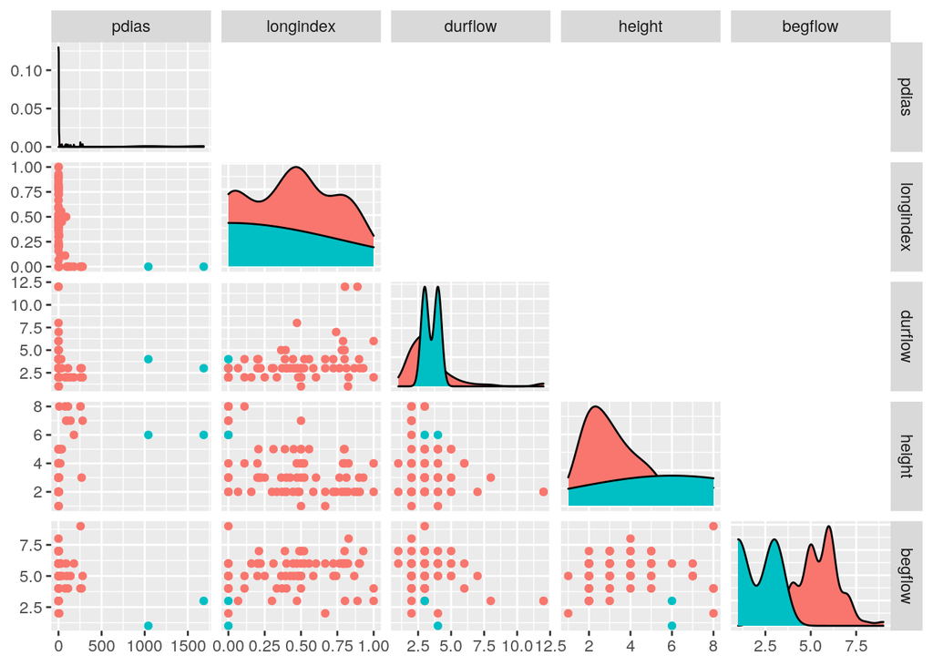

```r
# pairwise combinations
library(GGally)
ggpairs_data <- clust_data %>% mutate(cluster = as.factor(pamdata$clustering))
ggpairs(ggpairs_data[1:5], aes(color = as.factor(pamdata$clustering)),
    upper = NULL)
```

```r
# ggpairs(pam_data2,
# aes(color=as.factor(pamdata$clustering)), upper=NULL)

pam_data2 <- plant_data %>% mutate(cluster = as.factor(pamdata$clustering))
pam_data2 %>% filter(cluster == 2)
```

```
## # A tibble: 2 x 33
##   X1    pdias longindex durflow height begflow mycor vegaer vegsout autopoll
##   <chr> <dbl>     <dbl>   <dbl>  <dbl>   <dbl> <dbl>  <dbl>   <dbl>    <dbl>
## 1 Corav 1042          0       4      6       1     2      0       0        0
## 2 Prusi 1684.         0       3      6       3     1      0       2        1
## # … with 23 more variables: insects <dbl>, wind <dbl>, lign <dbl>, piq <dbl>,
## #   ros <dbl>, semiros <dbl>, leafy <dbl>, suman <dbl>, winan <dbl>,
## #   monocarp <dbl>, polycarp <dbl>, seasaes <dbl>, seashiv <dbl>,
## #   seasver <dbl>, everalw <dbl>, everparti <dbl>, elaio <dbl>, endozoo <dbl>,
## #   epizoo <dbl>, aquat <dbl>, windgl <dbl>, unsp <dbl>, cluster <fct>
```

```r
plant_data %>% slice(pamdata$id.med)
```

```
## # A tibble: 2 x 32
##   X1     pdias longindex durflow height begflow mycor vegaer vegsout autopoll
##   <chr>  <dbl>     <dbl>   <dbl>  <dbl>   <dbl> <dbl>  <dbl>   <dbl>    <dbl>
## 1 Geuur 2.45e0       0.2       4      3       5     2      0       0        3
## 2 Prusi 1.68e3       0         3      6       3     1      0       2        1
## # … with 22 more variables: insects <dbl>, wind <dbl>, lign <dbl>, piq <dbl>,
## #   ros <dbl>, semiros <dbl>, leafy <dbl>, suman <dbl>, winan <dbl>,
## #   monocarp <dbl>, polycarp <dbl>, seasaes <dbl>, seashiv <dbl>,
## #   seasver <dbl>, everalw <dbl>, everparti <dbl>, elaio <dbl>, endozoo <dbl>,
## #   epizoo <dbl>, aquat <dbl>, windgl <dbl>, unsp <dbl>
```

```r
# cluster means
pam_data2 %>% group_by(cluster) %>% summarize_if(is.numeric,
    mean, na.rm = T)
```

```
## # A tibble: 2 x 32
##   cluster  pdias longindex durflow height begflow mycor vegaer vegsout autopoll
##   <fct>    <dbl>     <dbl>   <dbl>  <dbl>   <dbl> <dbl>  <dbl>   <dbl>    <dbl>
## 1 1         25.7     0.434    3.37   3.57    5.26  1.55   0.25   0.421     1.01
## 2 2       1363.      0        3.5    6       2     1.5    0      1         0.5
## # … with 22 more variables: insects <dbl>, wind <dbl>, lign <dbl>, piq <dbl>,
## #   ros <dbl>, semiros <dbl>, leafy <dbl>, suman <dbl>, winan <dbl>,
## #   monocarp <dbl>, polycarp <dbl>, seasaes <dbl>, seashiv <dbl>,
## #   seasver <dbl>, everalw <dbl>, everparti <dbl>, elaio <dbl>, endozoo <dbl>,
## #   epizoo <dbl>, aquat <dbl>, windgl <dbl>, unsp <dbl>
```

```r
pamdata$silinfo$avg.width
```

```
## [1] 0.9498991
```

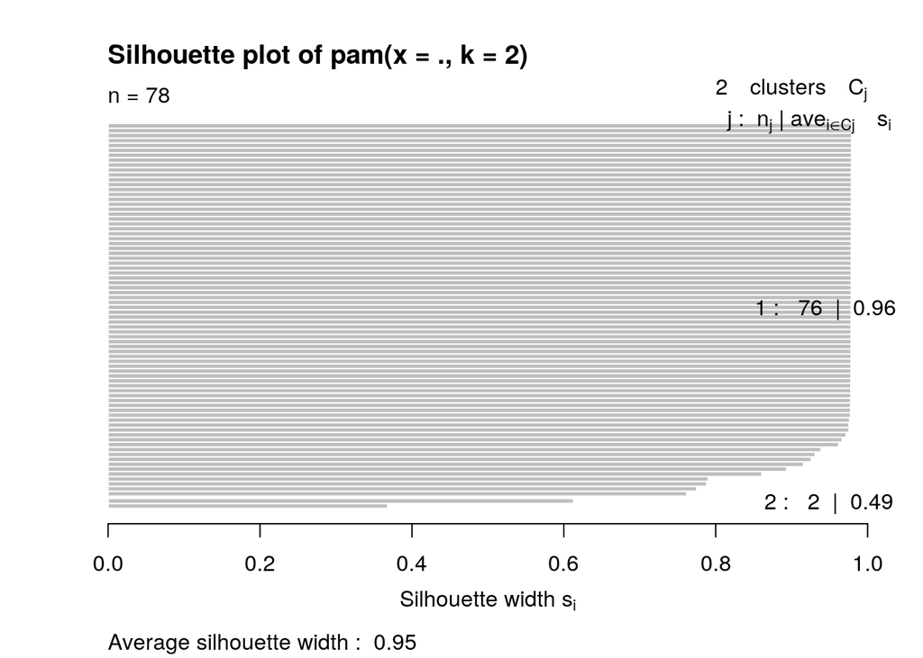

```r
plot(pamdata, which = 2)  #greater than 0.71 (a strong structure has been found)
```

*Based on the graph of silhouette width vs k, where the highest point is at k=2, it appears that two clusters best fits the data. PAM clustering revealed that the majority of the plant species fall under the first cluster, with only two observations (Corav and Prusi) making up the second cluster. The medoids of the clusters are Geuur for cluster 1 and Prusi for cluster 2.* *The mean values of the variables that help define the first cluster are a diaspore mass of 25.704 mg, seed bank longevity of 0.434, flowering duration of 3.368, ordered plant height of 3.566, and an ordered first flowering time of 5.263. The mean values of the variables that help define the second cluster are a diaspore mass of 1363.150 mg, seed bank longevity of 0.000, flowering duration of 3.500, plant height of 6.000, and an ordered first flowering time of 2.000. The goodness of fit is about 0.950, which is greater than 0.71 and indicates that a strong structure has been found in the cluster solution. (Only the first 5 out of 31 variables’ cluster means are discussed here for the sake of brevity and clarity, but all 31 cluster means can be found under #cluster means. Similarly, only the first 5 variables are used for ggpairs because having all 31 combinations makes the output too cluttered and difficult to visualize).*

### Dimensionality Reduction with PCA

```r
plant_nums <- plant_data %>% select_if(is.numeric) %>% scale()
rownames(plant_nums) <- plant_data$X1
plant_pca <- princomp(plant_nums)
plant_pca %>% names()
```

```
## [1] "sdev"     "loadings" "center"   "scale"    "n.obs"    "scores"   "call"
```

```r
plant_df <- data.frame(PC1 = plant_pca$loadings[, 1], PC2 = plant_pca$loadings[,
    2])
plant_df %>% head()
```

```
##                   PC1         PC2
## pdias      0.23570657  0.14525701
## longindex -0.26517870  0.00515102
## durflow   -0.18329986  0.15269608
## height     0.29224368  0.23927054
## begflow   -0.03908412 -0.01743316
## mycor      0.11578404 -0.06615038
```

```r
# variance
summary(plant_pca, loadings = T)
```

```
## Importance of components:
##                           Comp.1    Comp.2     Comp.3     Comp.4     Comp.5
## Standard deviation     2.2825593 1.8807909 1.55844154 1.52756244 1.38342650
## Proportion of Variance 0.1702497 0.1155908 0.07936394 0.07625005 0.06253949
## Cumulative Proportion  0.1702497 0.2858405 0.36520441 0.44145446 0.50399396
##                           Comp.6     Comp.7     Comp.8     Comp.9    Comp.10
## Standard deviation     1.3445402 1.24097342 1.16119801 1.15904475 1.10650290
## Proportion of Variance 0.0590731 0.05032307 0.04406104 0.04389778 0.04000804
## Cumulative Proportion  0.5630671 0.61339013 0.65745117 0.70134895 0.74135700
##                           Comp.11    Comp.12    Comp.13    Comp.14   Comp.15
## Standard deviation     1.05865503 1.01679610 0.91335711 0.84273828 0.8263532
## Proportion of Variance 0.03662276 0.03378391 0.02725985 0.02320746 0.0223138
## Cumulative Proportion  0.77797976 0.81176367 0.83902352 0.86223098 0.8845448
##                           Comp.16    Comp.17    Comp.18    Comp.19    Comp.20
## Standard deviation     0.72007922 0.69993886 0.68193986 0.61689217 0.59570293
## Proportion of Variance 0.01694349 0.01600893 0.01519618 0.01243543 0.01159583
## Cumulative Proportion  0.90148827 0.91749720 0.93269338 0.94512880 0.95672463
##                            Comp.21   Comp.22     Comp.23     Comp.24
## Standard deviation     0.552834311 0.4926736 0.464214741 0.423732457
## Proportion of Variance 0.009986934 0.0079316 0.007041741 0.005867129
## Cumulative Proportion  0.966711563 0.9746432 0.981684903 0.987552032
##                            Comp.25   Comp.26     Comp.27   Comp.28      Comp.29
## Standard deviation     0.374185093 0.3024317 0.287412077 0.1972514 0.1269702751
## Proportion of Variance 0.004575253 0.0029888 0.002699307 0.0012714 0.0005268007
## Cumulative Proportion  0.992127286 0.9951161 0.997815392 0.9990868 0.9996135933
##                             Comp.30 Comp.31
## Standard deviation     0.1087429845       0
## Proportion of Variance 0.0003864067       0
## Cumulative Proportion  1.0000000000       1
##
## Loadings:
##           Comp.1 Comp.2 Comp.3 Comp.4 Comp.5 Comp.6 Comp.7 Comp.8 Comp.9
## pdias      0.236  0.145  0.116         0.261                0.354
## longindex -0.265        -0.115        -0.288  0.190  0.136         0.162
## durflow   -0.183  0.153         0.172                0.151  0.338  0.265
##           Comp.10 Comp.11 Comp.12 Comp.13 Comp.14 Comp.15 Comp.16 Comp.17
## pdias      0.121                           0.126   0.170   0.263   0.420
## longindex                  0.101           0.165   0.167           0.230
## durflow    0.106   0.195  -0.234  -0.265  -0.163  -0.157          -0.177
##           Comp.18 Comp.19 Comp.20 Comp.21 Comp.22 Comp.23 Comp.24 Comp.25
## pdias              0.285           0.184           0.498
## longindex  0.127   0.165   0.315  -0.628   0.122          -0.141   0.114
## durflow   -0.312           0.416   0.194   0.166           0.143   0.129
##           Comp.26 Comp.27 Comp.28 Comp.29 Comp.30 Comp.31
## pdias      0.127
## longindex
## durflow   -0.221   0.113
##  [ reached getOption("max.print") -- omitted 28 rows ]
```

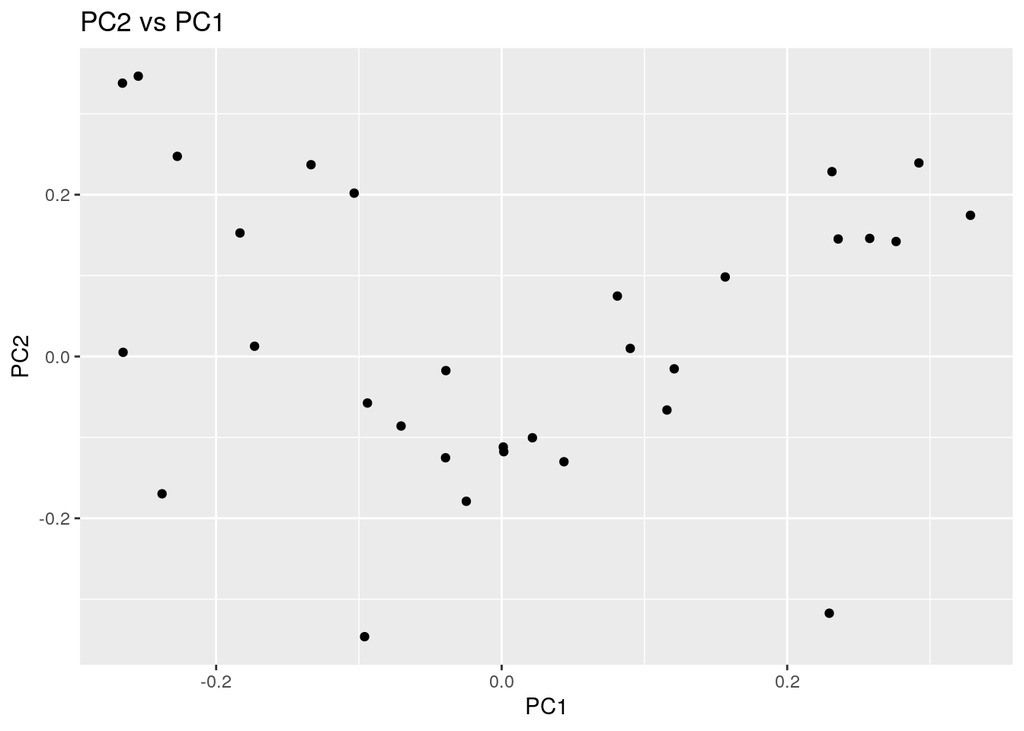

```r
# visualization
ggplot(plant_df, aes(PC1, PC2)) + geom_point() + ggtitle("PC2 vs PC1")
```

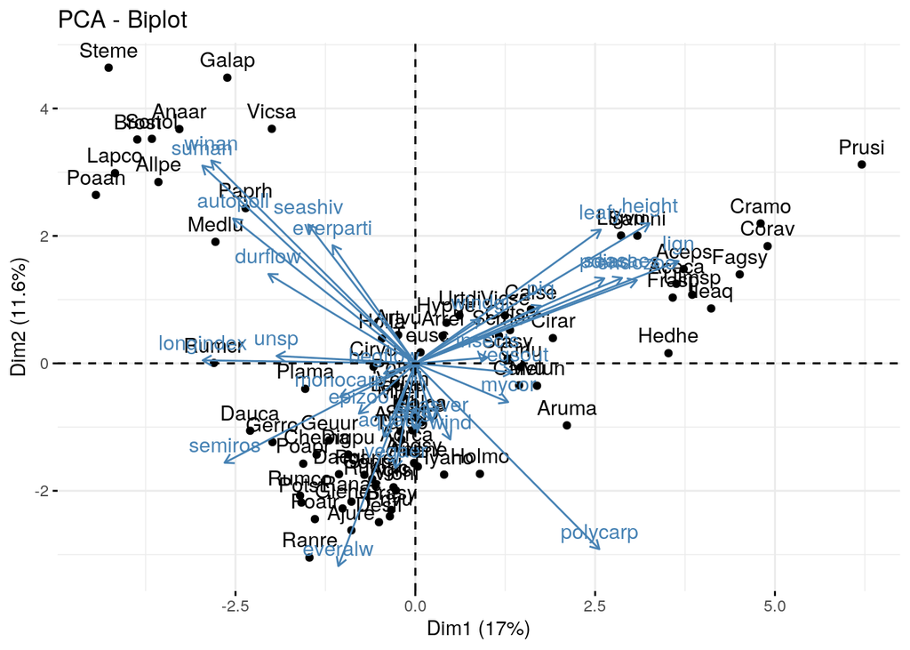

```r
library(factoextra)
fviz_pca_biplot(plant_pca)
```

*The total variance of the dataset that is explained by PC1 and PC2 is only 28.584%. Each principle component only accounts for a small amount of variation in the dataset. It would take five principle components to encompass 50% of the total variance.*

### Linear Classifier

```r
fit_lc <- glm(leafy ~ pdias + longindex + durflow + height +
    begflow + mycor + vegaer + vegsout + autopoll + insects,
    data = plant_data, family = "binomial")
score_lc <- predict(fit_lc)
score_lc %>% round(3)
```

```
##      1      2      3      4      5      6      7      8      9     10     11
##  2.002  2.578 -0.479  0.305  0.062  0.265 -0.874  0.250 -0.889 -2.390  2.827
##     12     13     14     15     16     17     18     19     20     21     22
##  1.310  0.264  0.558 -0.879  3.083  0.397 -1.118  3.780  1.955  0.821 -2.211
##     23     24     25     26     27     28     29     30     31     32     33
##  2.585  3.230 -0.268 -1.412 -1.815 -2.436 -0.805  0.937  3.097  2.447  1.796
##     34     35     36     37     38     39     40     41     42     43     44
## -0.367 -0.198 -1.897  8.469 -0.476  1.382 -3.667  2.782  2.156  0.682 -0.832
##     45     46     47     48     49     50     51     52     53     54     55
##  3.016 -0.861  0.213 -1.300 -0.434 -3.743 -0.510 -1.263 -0.710 -0.273 -1.718
##     56     57     58     59     60     61     62     63     64     65     66
##  0.229 -2.485 -4.399  9.792 -1.493  0.026 -1.778 -0.695 -1.740  3.330  2.056
##     67     68     69     70     71     72     73     74     75     76     77
##  1.537  2.849 -0.100 -1.985 -2.508  4.668  2.950  3.877  0.979  1.670  4.027
##     78
## -2.619
```

```r
class_diag(score_lc, truth = plant_data$leafy, positive = 1)
```

```
##            acc   sens   spec   ppv     f1     ba    auc
## Metrics 0.7692 0.6667 0.8889 0.875 0.7568 0.7778 0.8677
```

```r
library(caret)
knn_fit <- knn3(factor(leafy == 1, levels = c("TRUE", "FALSE")) ~
    pdias + longindex + durflow + height + begflow + mycor +
        vegaer + vegsout + autopoll + insects, data = plant_data,
    k = 5)
y_hat_knn <- predict(knn_fit, plant_data)
class_diag(y_hat_knn[, 1], plant_data$leafy, positive = 1)
```

```
##            acc   sens   spec    ppv     f1     ba    auc
## Metrics 0.7564 0.6905 0.8333 0.8286 0.7532 0.7619 0.8694
```

```r
# confusion matrix
table(truth = factor(plant_data$leafy == 1, levels = c("TRUE",
    "FALSE")), prediction = factor(y_hat_knn[, 1] > 0.5, levels = c("TRUE",
    "FALSE")))
```

```
##        prediction
## truth   TRUE FALSE
##   TRUE    29    13
##   FALSE    6    30
```

*Using logistic regression to predict the variable “leafy” from the the first ten variables in the dataset yields an AUC of about 0.868 and indicates that the logistic regression model is making fairly accurate predictions.*

```r
set.seed(123)
k = 10
data <- plant_data[sample(nrow(plant_data)), ]
folds <- cut(seq(1:nrow(plant_data)), breaks = k, labels = F)
diags <- NULL
for (i in 1:k) {
    train <- data[folds != i, ]
    test <- data[folds == i, ]
    truth <- test$leafy
}
fit_lc2 <- glm(leafy ~ pdias + longindex + durflow + height +
    begflow + mycor + vegaer + vegsout + autopoll + insects,
    data = train, family = "binomial")
probs_lc2 <- predict(fit_lc2, newdata = test, type = "response")
diags <- rbind(diags, class_diag(probs_lc2, truth, positive = 1))
summarize_all(diags, mean)
```

```
##   acc sens   spec    ppv  f1     ba auc
## 1 0.5  0.4 0.6667 0.6667 0.5 0.5333 0.8
```

*After performing cross validation the AUC of the model is 0.8 (for seed 123). The AUC decreased in comparison to the original logistic regression model which indicates that the model may be overfitting.*

### Non-Parametric Classifier

```r
plant_data$leafyTF <- ifelse(plant_data$leafy == 1, "leafy",
    "not_leafy")
plant_data %>% select(leafy, leafyTF) %>% head()
```

```
## # A tibble: 6 x 2
##   leafy leafyTF
##   <dbl> <chr>
## 1     1 leafy
## 2     1 leafy
## 3     1 leafy
## 4     1 leafy
## 5     0 not_leafy
## 6     0 not_leafy
```

```r
# classification tree
fit_npc <- train(leafyTF ~ pdias + longindex + durflow + height +
    begflow + mycor + vegaer + vegsout + autopoll + insects,
    data = plant_data, method = "rpart")
library(rpart.plot)
fit_npc$bestTune
```

```
##           cp
## 1 0.02777778
```

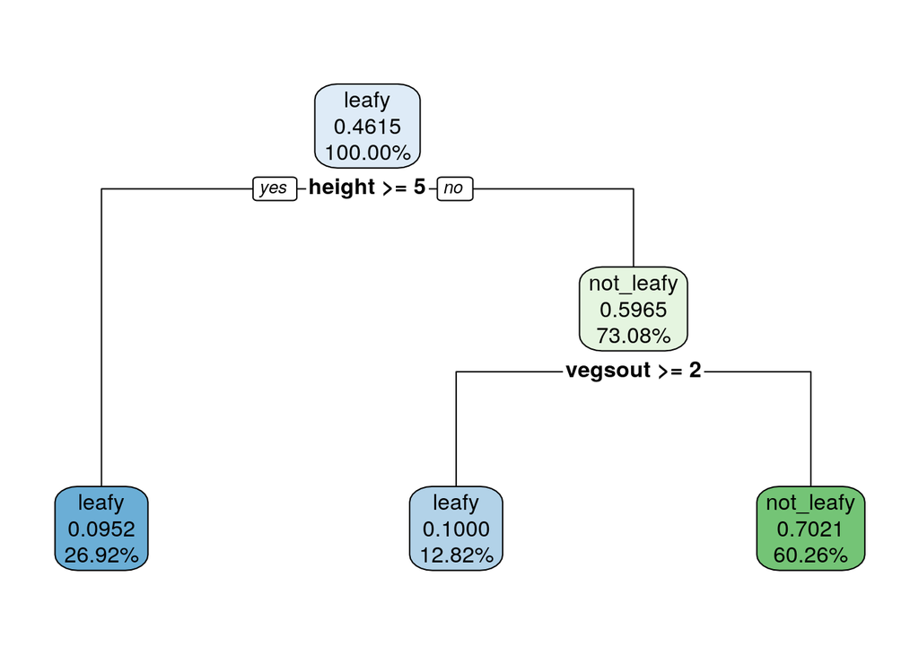

```r
rpart.plot(fit_npc$finalModel, digits = 4)
```

```r
# AUC
class_diag(predict(fit_npc, type = "prob")[, 2], plant_data$leafyTF,
    positive = "leafy")
```

```
##            acc   sens   spec    ppv     f1     ba   auc
## Metrics 0.2179 0.3333 0.0833 0.2979 0.3146 0.2083 0.208
```

```r
# confusion matrix
table(actual = plant_data$leafyTF, pred = predict(fit_npc))[c(2,
    1), c(2, 1)]
```

```
##            pred
## actual      not_leafy leafy
##   not_leafy        33     3
##   leafy            14    28
```

```r
# cross validation
set.seed(123)
cv <- trainControl(method = "cv", number = 10, classProbs = T,
    savePredictions = T)
fit_npc_cv <- train(leafyTF ~ pdias + longindex + durflow + height +
    begflow + mycor + vegaer + vegsout + autopoll + insects,
    data = plant_data, trControl = cv, method = "rpart")
class_diag(fit_npc_cv$pred$leafy, fit_npc_cv$pred$obs, positive = "leafy")
```

```
##            acc   sens   spec    ppv     f1     ba    auc
## Metrics 0.6111 0.6111 0.6111 0.6471 0.6286 0.6111 0.6324
```

*To predict “leafy” with a non-parametric classifier I used a classification tree. The classification tree shows that the first two splits for determining “leafy” come from the variable “height” and “vegsout”. If the plant species is taller (greater than or equal to the ordered height value of 5) then it is predicted to be leafy. If the plant species is shorter than 5 but has important underground vegetative propagation (vegsout greater than or equal to 2) then the plant species is also predicted to be leafy. Otherwise it is predicted to not be leafy.*

### Regression/Numeric Prediction

```r
fit_lr <- lm(height ~ pdias + longindex + durflow + begflow +
    mycor + vegaer + vegsout + autopoll + insects, data = plant_data)
yhat_lr <- predict(fit_lr)
mean((plant_data$height - yhat_lr)^2)  #MSE
```

```
## [1] 2.119745
```

```r
# cross validation
set.seed(123)
k = 10
data_lr <- plant_data[sample(nrow(plant_data)), ]
folds_lr <- cut(seq(1:nrow(plant_data)), breaks = k, label = F)
MSE <- NULL

for (i in 1:k) {
    train_lr <- data[folds != i, ]
    test_lr <- data[folds == i, ]
    truth <- test_lr$height

    fit_lrcv <- lm(height ~ pdias + longindex + durflow + begflow +
        mycor + vegaer + vegsout + autopoll + insects, data = train)
    yhat_lrcv <- predict(fit_lrcv, newdata = test_lr)
    MSE <- cbind(MSE, mean((truth - yhat_lrcv)^2))
}
mean(MSE)
```

```
## [1] 2.256799
```

*The MSE of the linear regression model is approximately 2.120. After performing cross validation the average MSE is about 2.257 (for seed 123). Since the MSE increased in cross validation this indicates that the linear regression model is slightly overfitting.*

### Python

```r
library(reticulate)
use_python("/usr/bin/python3")
plot <- import("matplotlib")
plot$use("Agg", force = TRUE)
```

```python
r.plant_data.head()
```

```
##       X1   pdias  longindex  durflow  ...  aquat  windgl  unsp    leafyTF
## 0  Aceca   96.84   0.000000      2.0  ...    0.0     1.0   0.0      leafy
## 1  Aceps  110.72   0.000000      3.0  ...    0.0     1.0   0.0      leafy
## 2  Agrca    0.06   0.666667      3.0  ...    0.0     0.0   1.0      leafy
## 3  Agrst    0.08   0.488889      2.0  ...    0.0     0.0   1.0      leafy
## 4  Ajure    1.48   0.476190      3.0  ...    0.0     0.0   0.0  not_leafy
##
## [5 rows x 33 columns]
```

```python
r.plant_data["leafy"].head()
```

```
## 0    1.0
## 1    1.0
## 2    1.0
## 3    1.0
## 4    0.0
## Name: leafy, dtype: float64
```

```python
leafy_py=r.plant_data["leafy"]
```

```r
cat(py$leafy_py)
```

```
## 1 1 1 1 0 0 1 0 0 1 1 1 0 0 0 1 1 0 1 1 0 0 1 1 1 0 0 0 0 1 1 1 1 0 0 0 1 1 1 0 1 1 0 1 1 1 1 1 0 0 0 0 0 0 0 1 0 0 1 0 0 0 0 0 1 1 0 1 1 1 0 1 1 1 1 1 1 0
```

*Using python and reticulate I opened the plant_data dataset in a python code chunk, indexed the variable “leafy”, and then assigned it to “leafy_py”. Then I accessed “leafy_py” in an r code chunk using py$.*

```r
pdias <- plant_data$pdias
long <- plant_data$longindex
```

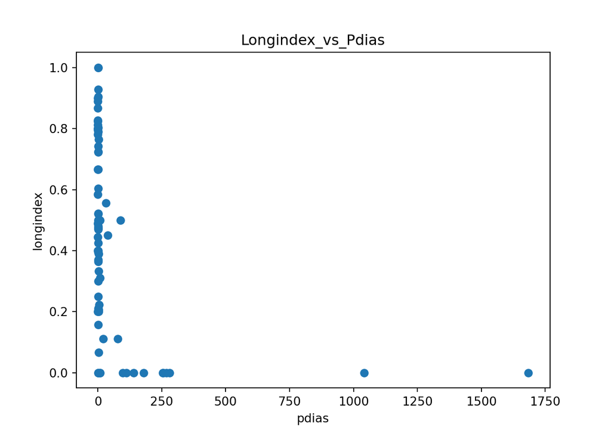

```python
import matplotlib.pyplot as plt
x=r.pdias
y=r.long
plt.scatter(x,y)
plt.xlabel('pdias')
plt.ylabel('longindex')
plt.title('Longindex_vs_Pdias')
plt.show()
```

*Using python and reticulate I made two vectors containing the first two variables of the plant_data dataset and then used the vectors in a python code chunk to create a scatterplot of pdias (diaspore mass) vs longindex (seed bank longevity).*

### Data Citation

Vallet, Jeanne (2005) Structuration de communautés végétales et analyse comparative de traits biologiques le long d’un gradient d’urbanisation. Mémoire de Master 2 ‘Ecologie-Biodiversité-Evolution’; Université Paris Sud XI, 30p.+ annexes (in french)